# Crafting Publication-Ready Graphics in R

Facets, coordinates, annotations, themes, and professional export in ggplot2

Bogdan G. Popescu

bogdan.popescu@johncabot.edu

John Cabot University

## Introduction

Today we move beyond geoms/aesthetics to **compose, clarify, and polish** plots.

- **Facets vs. color/fill:** when to split panels vs. overlay groups.
- **Coordinates for honesty:** `coord_cartesian()` (zoom w/o dropping), `coord_flip()` (long labels). *Beware truncated axes.*
- **Annotations that guide the eye:** `geom_text()`, `geom_label()`, `ggrepel`, arrows/callouts.
- **Themes that professionalize:** built-ins (`gray`, `bw`, `minimal`, `classic`, `void`) + `ggthemes` (e.g., *economist*, *wsj*); quick tweaks.
- **Combining, motion, export:** `ggarrange()` • `gganimate`/`ggiraph` • `ggsave` (formats, aspect, DPI).

## Simple Geoms

### Aesthetics & the Layer Cake

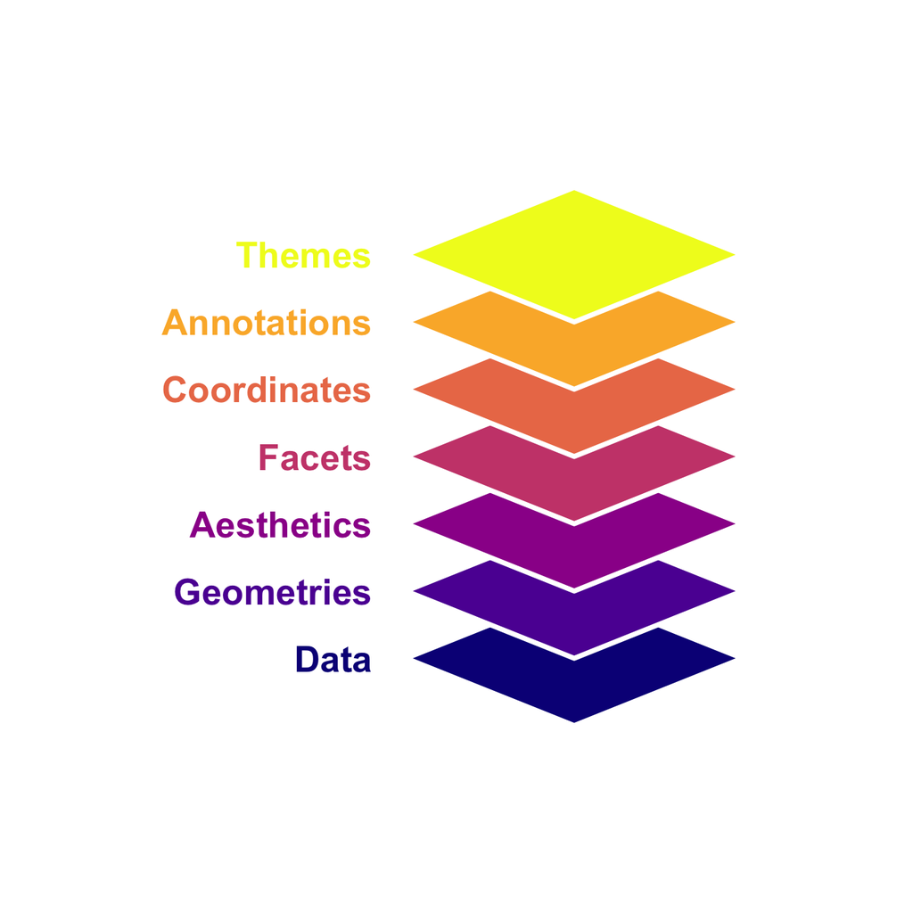

## Simple Geoms

### Aesthetics & the Layer Cake

- **Geoms** are the marks (points, lines, bars) your data takes on a plot.
- **Aesthetics**: color, fill, size, shape, alpha, linetype.
- Today’s focus:
  - **Facets** (small multiples)
  - **Coordinates** (zoom/flip)
  - **Annotations** (guide the eye)
  - **Themes** (professional polish).

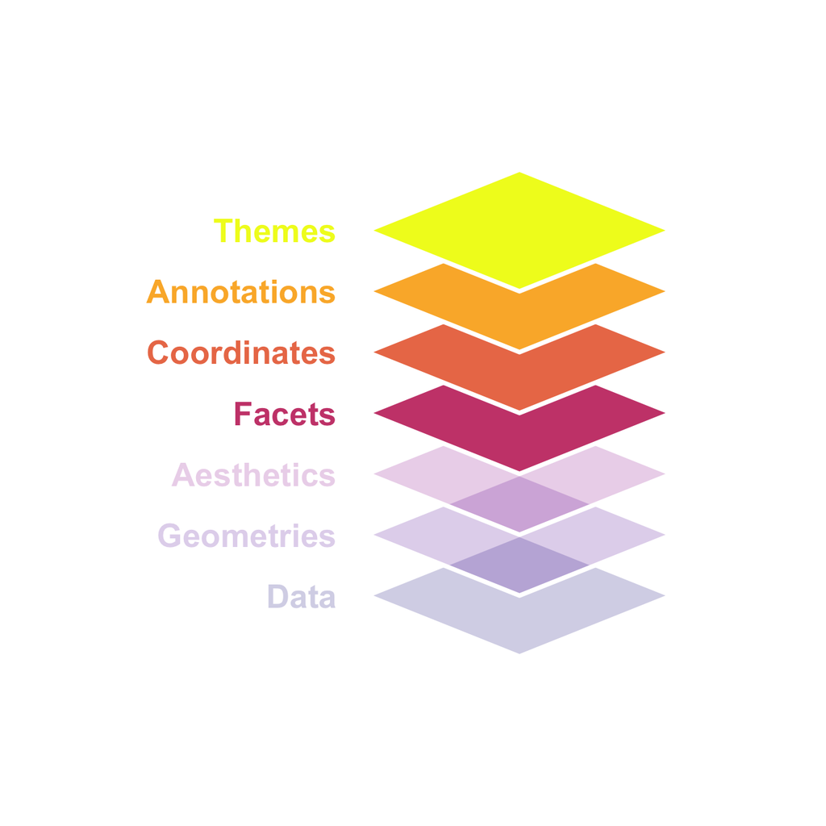

# Facets

## Facets

### What are they?

Facets split the data into multiple small plots (panels).

- Each panel shows only the subset of data for that category.

**When to use facets?**

- When you want to give each group its own space (avoid overlap/clutter).
- When the comparison you care about is between panels, not within the same axes.

**When to use color/fill aesthetics?**

- When you want to directly compare groups side by side on the same scale.
- When the overlap is not a problem, or even desirable

## Facets

### geom_line

Suppose we have data on average voter turnout (%) in national elections over several years for the US and the UK. We want to see the trend in participation.

This is our dataset:

```r
library(ggplot2)
set.seed(123)

# Toy dataset with US and UK
eg5 <- data.frame(
  year = rep(c(2000, 2004, 2008, 2012, 2016, 2020), times = 2),
  turnout = c(
    # US presidential elections
    54, 60, 62, 58, 56, 65,
    # UK general elections (closest years aligned to US election years for teaching)
    59, 61, 65, 66, 68, 67
  ),
  country = rep(c("United States", "United Kingdom"), each = 6)
)
```

## Facets

### geom_line

Suppose we have data on average voter turnout (%) in national elections over several years for the US and the UK. We want to see the trend in participation.

This is what it looks like:

| year | turnout | country |
| --- | --- | --- |
| 2000 | 54 | United States |
| 2004 | 60 | United States |
| 2008 | 62 | United States |
| 2012 | 58 | United States |
| 2016 | 56 | United States |
| 2020 | 65 | United States |
| 2000 | 59 | United Kingdom |

## Facets

### geom_line

Suppose we have data on average voter turnout (%) in national elections over several years for the US and the UK. We want to see the trend in participation.

This is what we had previously:

```r
ggplot(eg5, aes(x = year, y = turnout, color = country)) +
  geom_line()
```

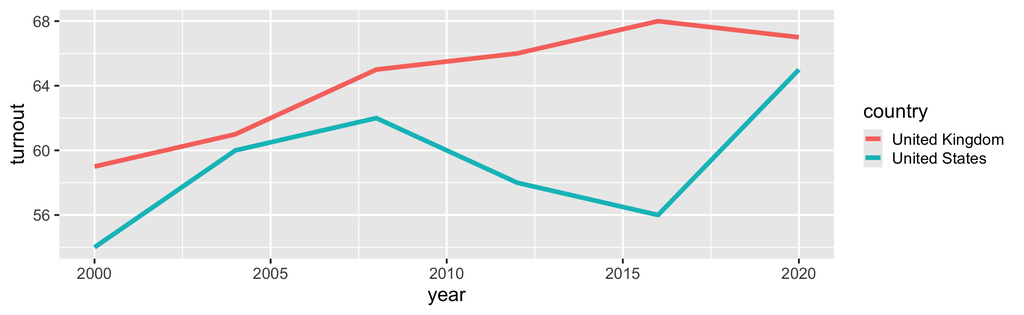

## Facets

### geom_line

Suppose we have data on average voter turnout (%) in national elections over several years for the US and the UK. We want to see the trend in participation.

This is the alternative using facets:

```r
ggplot(eg5, aes(x = year, y = turnout)) +
  geom_line() +
  facet_wrap(~ country, ncol = 1)
```

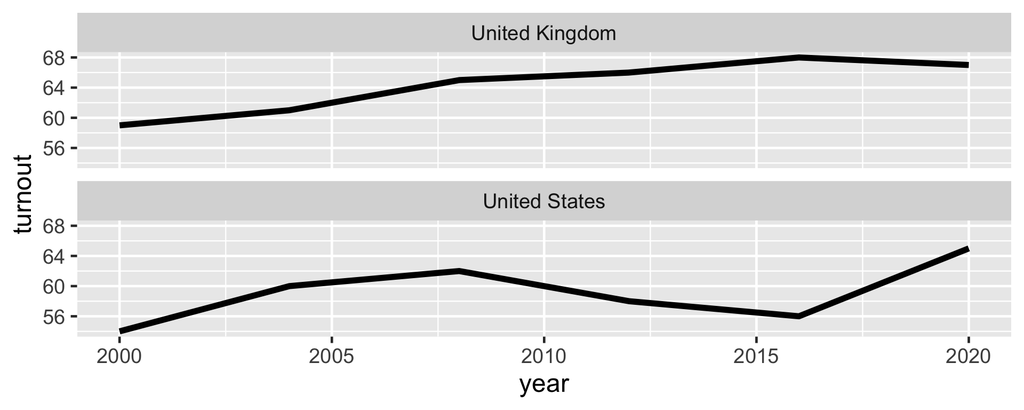

## Facets

### geom_histogram

Suppose we surveyed people about their trust in government on a 1–10 scale (1 = no trust, 10 = complete trust). We want to compare typical values and how spread out the answers are for men and women.

This is our dataset:

```r
library(ggplot2)
set.seed(123)
# Toy survey dataset
eg6 <- data.frame(
  gender = rep(c("Men", "Women"), each = 20),
  trust = c(
    rnorm(20, mean = 5, sd = 2),
    rnorm(20, mean = 8, sd = 1)
  )
)
```

## Facets

### geom_histogram

Suppose we surveyed people about their trust in government on a 1–10 scale (1 = no trust, 10 = complete trust). We want to compare typical values and how spread out the answers are for men and women.

This is what it looks like:

| gender | trust |
| --- | --- |
| Men | 3.879049 |
| Men | 4.539645 |
| Men | 8.117417 |
| Men | 5.141017 |
| Men | 5.258576 |

## Facets

### geom_histogram

Suppose we surveyed people about their trust in government on a 1–10 scale (1 = no trust, 10 = complete trust). We want to compare typical values and how spread out the answers are for men and women.

This is what we had previously:

```r
ggplot(eg6, aes(x = trust, fill = gender)) +
  geom_histogram(bins = 10, color = "white", alpha = 0.5)
```

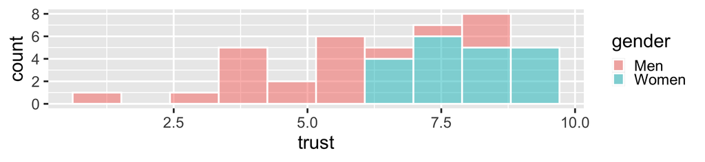

## Facets

### geom_histogram

Suppose we surveyed people about their trust in government on a 1–10 scale (1 = no trust, 10 = complete trust). We want to compare typical values and how spread out the answers are for men and women.

This is the alternative using facets:

```r
ggplot(eg6, aes(x = trust)) +
  geom_histogram(bins = 10, color = "white") +
  facet_wrap(~ gender, ncol = 1)               # one panel per gender
```

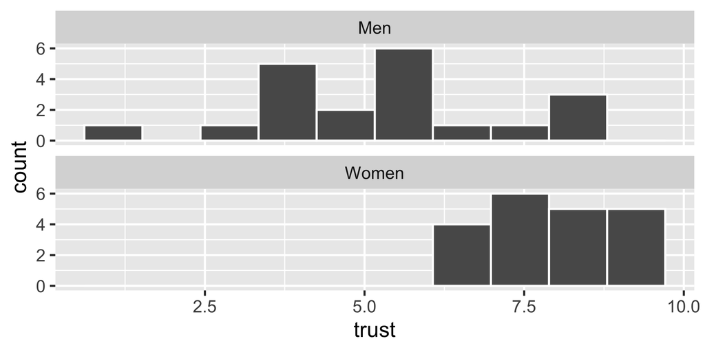

## Putting Plots Side by Side

### `ggarrange()`

Sometimes you don’t want facets (splitting one dataset).

Instead, you might want to combine different plots — for example:

```r
library(ggpubr)

# Plot 1: voter turnout
p1 <- ggplot(eg5, aes(x = year, y = turnout, color = country, group = country)) +
  geom_line(linewidth=1.2) +
  labs(title = "Voter Turnout")

# Plot 2: trust in government
p2 <- ggplot(eg6, aes(x = trust, fill = gender)) +
  geom_histogram(bins = 10, color = "white", alpha = 0.7) +
  labs(title = "Trust in Government")

# Arrange them side by side
ggarrange(p1, p2, ncol = 2)
```

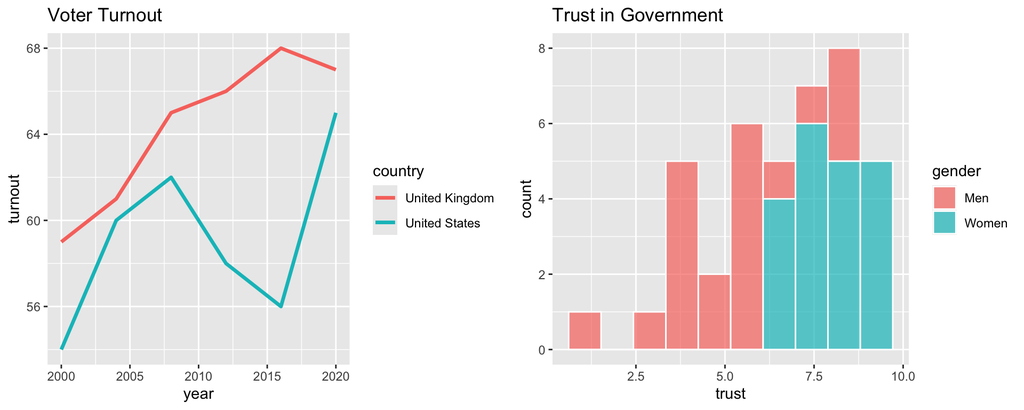

# Coordinates

## Coordinates

### Coordinates in ggplot2

- Control how data space is mapped to the plot space
- Can zoom in/out or flip axes
- Crucial for **clarity** and **honesty** in visualizations

Common functions:

- `coord_cartesian()` – zoom without dropping data
- `coord_flip()` – swap x & y axes (useful for long labels)

## Coordinates

### coord_cartesian

Let us check out another toy example inspired by real data.

The data looks like this:

```r
brexit_data <- data.frame(
  side = c("Leave", "Remain"),
  support = c(52, 48))
```

| side | support |
| --- | --- |
| Leave | 52 |
| Remain | 48 |

## Coordinates

### coord_cartesian

This is how we can plot our data:

```r
ggplot(brexit_data, aes(x = side, y = support, fill = side)) +
  geom_col()
```

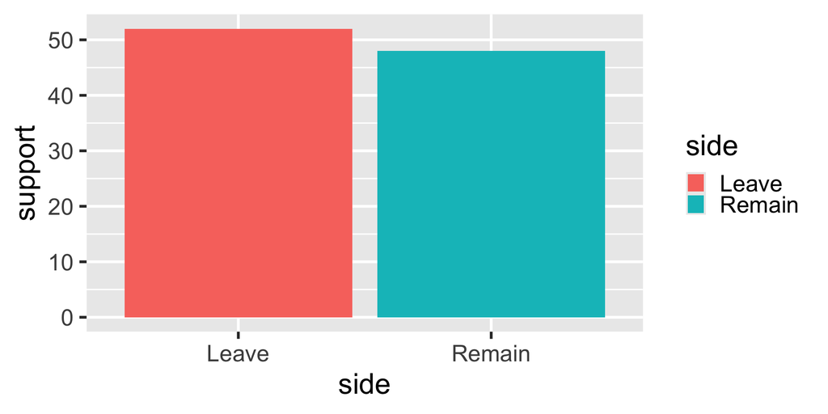

## Coordinates

### coord_cartesian

This is how we can truncate the axis (zoom the view) without dropping data:

```r
ggplot(brexit_data, aes(x = side, y = support, fill = side)) +
  geom_col() +
  coord_cartesian(ylim = c(45, 55))  # Truncates axis and exaggerates gap
```

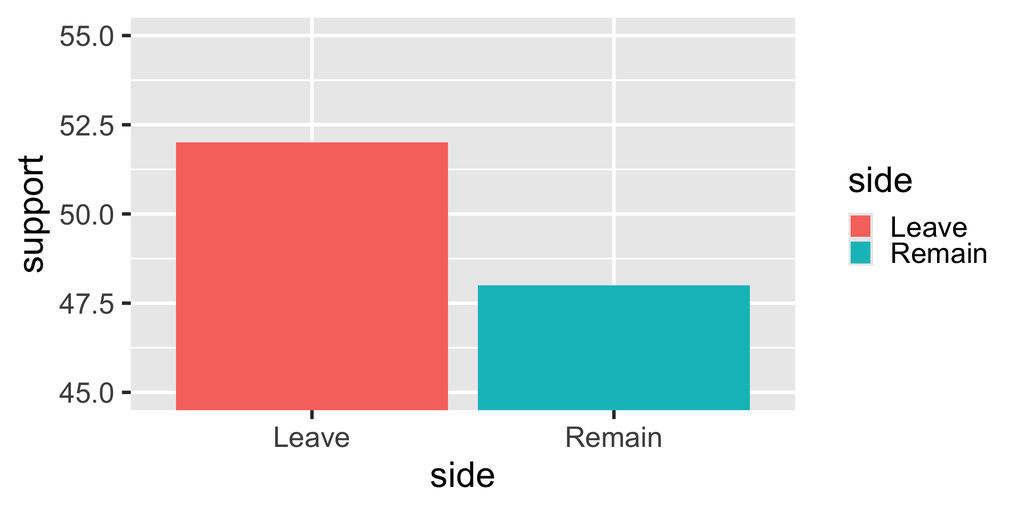

## Coordinates

### coord_cartesian

Moral: Truncated axes exaggerate differences.

## Flipping

### coord_flip

- `coord_flip()` swaps x and y axes, rotating the entire plot.
- Useful for bar charts with long category labels (improves readability).
- Often makes rankings and comparisons easier to interpret.

## Flipping

### coord_flip

```r
# Pre-aggregated counts instead of raw rows
eg2 <- data.frame(
  education = c(
    "Primary", "Primary", "High School", "High School", "High School",
    "College", "College", "College", "College"
  ))
```

| education |
| --- |
| Primary |
| Primary |
| High School |
| High School |

## Flipping

### coord_flip

```r
ggplot(eg2, aes(x = education)) +
  geom_bar()
```

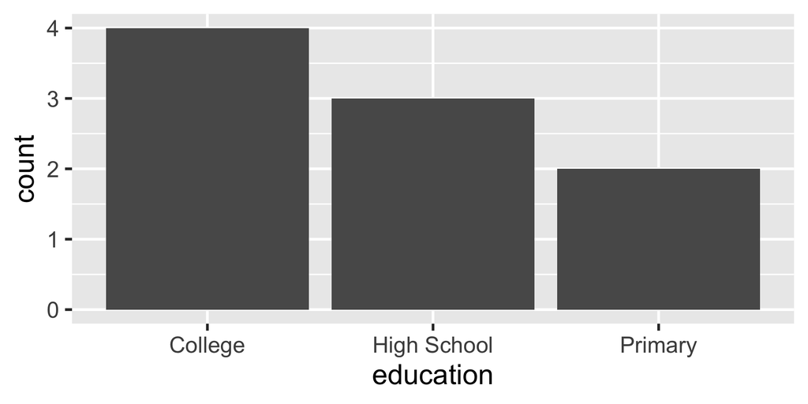

## Flipping

### coord_flip

This is how we can use `coord_flip`

```r
ggplot(eg2, aes(x = education)) +
  geom_bar()+
  coord_flip()
```

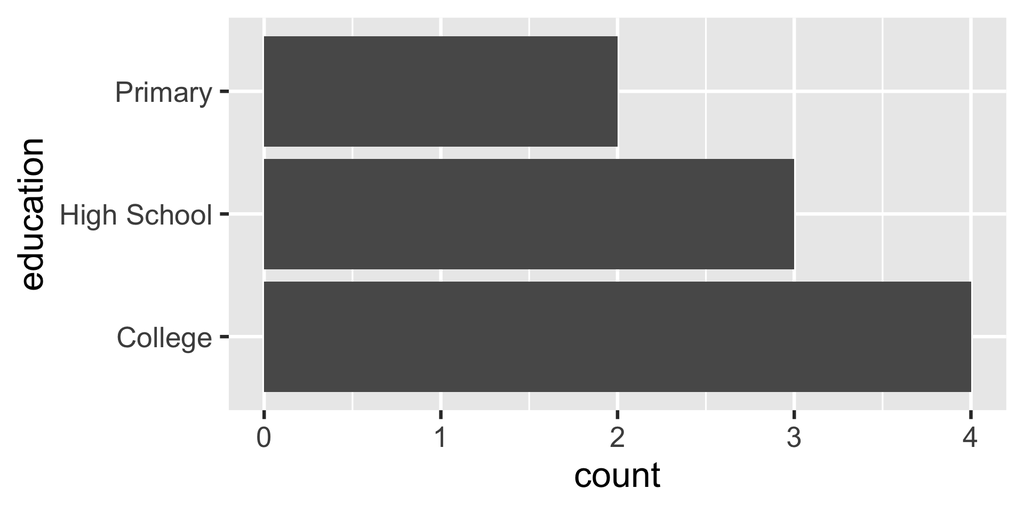

# Annotations

## Annotations

### Why Annotations?

Raw plots ≠ finished plots.

Annotations direct the reader’s eye and add context.

**Labels vs Annotations**

- **Labels**: Titles, axis labels, captions (labs()).
- **Annotations**: Extra text, marks on the plot itself

## Annotations

### `geom_text`

We learned to use `geom_text` in this example:

Imagine we have data about 9 countries that record their level of democracy from -10 to +10 (x-axis) and their GDP per capita in $1,000s (y-axis).

```r
eg1 <- data.frame(
  democracy = c(-8, -7, -5, -3, 0, 2, 5, 8, 9),   # democracy score
  gdp = c(2, 9, 4, 7, 8, 20, 15, 25, 27),  # GDP per capita in $1,000s
  country = c(
    "North Korea",   # very autocratic, very poor
    "Saudi Arabia",  # autocratic, but richer due to oil
    "Zimbabwe",      # authoritarian, low GDP
    "Russia",        # hybrid regime, middle income
    "Nigeria",       # similar position
    "India",         # low–mid democracy, growing GDP
    "Brazil",        # democracy, mid GDP
    "Poland",        # consolidated democracy, higher GDP
    "South Korea"))   # rich democracy
```

## Annotations

### `geom_text`

We learned to use `geom_text` in this example:

Imagine we have data about 9 countries that record their level of democracy from -10 to +10 (x-axis) and their GDP per capita in $1,000s (y-axis).

| democracy | gdp | country |
| --- | --- | --- |
| -8 | 2 | North Korea |
| -7 | 9 | Saudi Arabia |
| -5 | 4 | Zimbabwe |
| -3 | 7 | Russia |
| 0 | 8 | Nigeria |

## Annotations

### `geom_text`

We learned to use `geom_text` in this example:

Imagine we have data about 9 countries that record their level of democracy from -10 to +10 (x-axis) and their GDP per capita in $1,000s (y-axis).

```r
# Scatterplot with geom_point
ggplot(eg1, aes(x = democracy, y = gdp)) +
  geom_point(size = 5) +
  geom_text(aes(label = country), vjust = -1, size = 5)
```

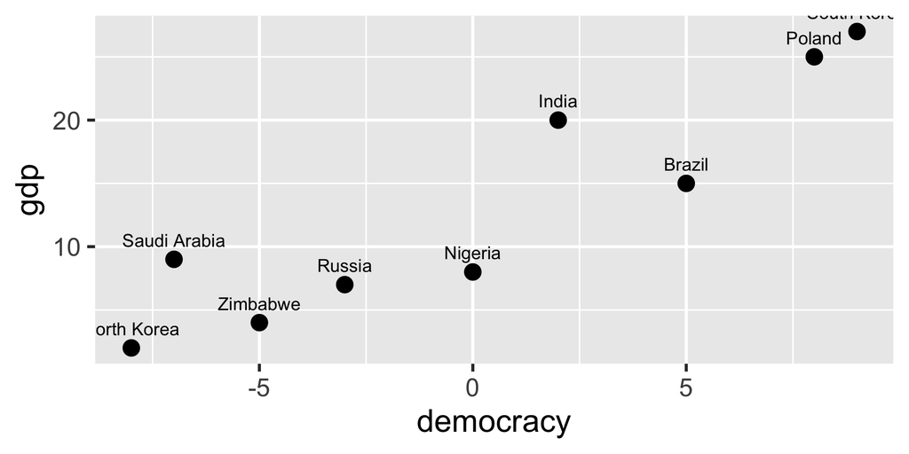

## Annotations

### `geom_label`

We could also use `geom_label` in this example:

Imagine we have data about 9 countries that record their level of democracy from -10 to +10 (x-axis) and their GDP per capita in $1,000s (y-axis).

```r
# Scatterplot with geom_point
ggplot(eg1, aes(x = democracy, y = gdp)) +
  geom_point(size = 5) +
  geom_label(aes(label = country), vjust = -1, size = 5)
```

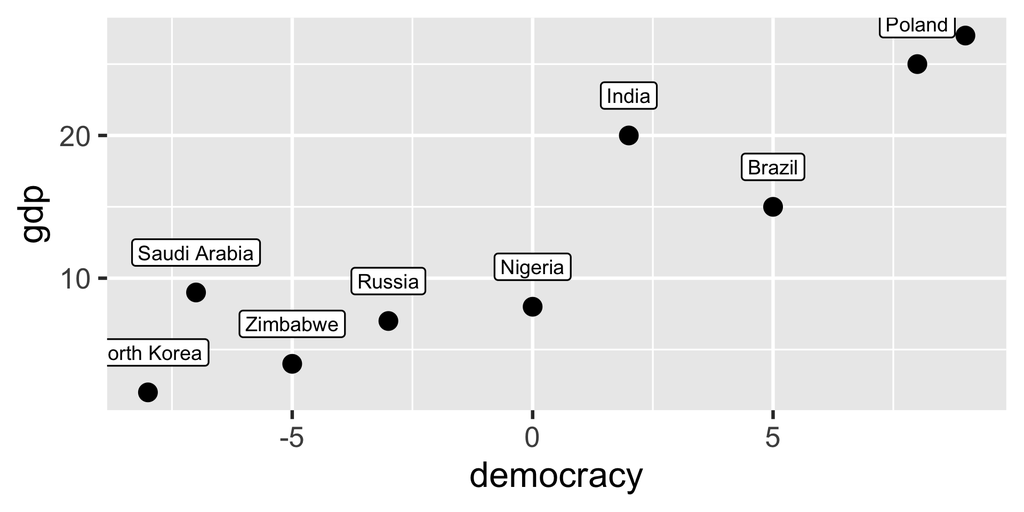

## Annotations

### `geom_text_repel`

We could also use `geom_text_repel` in this example to avoid clutter:

Imagine we have data about 9 countries that record their level of democracy from -10 to +10 (x-axis) and their GDP per capita in $1,000s (y-axis).

```r
library(ggrepel)

# Scatterplot with geom_point
ggplot(eg1, aes(x = democracy, y = gdp)) +
  geom_point(size = 5) +
  geom_text_repel(aes(label = country), size = 5)
```

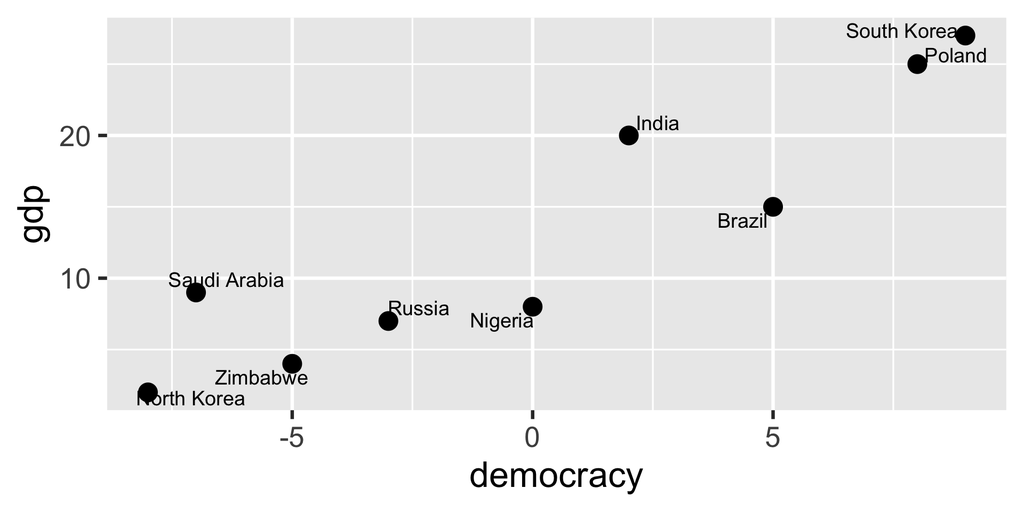

## Annotations

### `geom_label_repel`

We could also use `geom_label_repel` in this example to avoid clutter:

Imagine we have data about 9 countries that record their level of democracy from -10 to +10 (x-axis) and their GDP per capita in $1,000s (y-axis).

```r
library(ggrepel)
# Scatterplot with geom_point
ggplot(eg1, aes(x = democracy, y = gdp)) +
  geom_point(size = 5) +
  geom_label_repel(aes(label = country), size = 5)
```

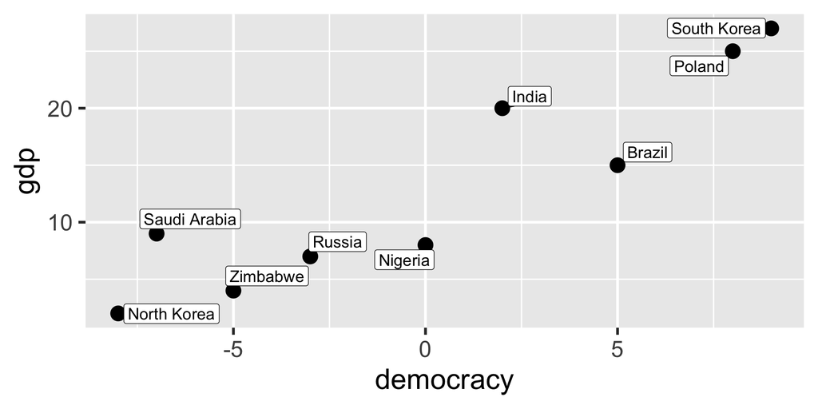

## Annotations

### `geom_text`

We learned to use `geom_text` in this example:

Imagine we have data about 9 countries that record their level of democracy from -10 to +10 (x-axis) and their GDP per capita in $1,000s (y-axis).

```r
# Scatterplot with geom_point
ggplot(eg1, aes(x = democracy, y = gdp)) +
  geom_point(size = 5) +
  geom_text(aes(label = country), vjust = -1, size = 5) +
  annotate("text", x = -7, y = 11, label = "Oil-rich outlier",
           color = "red", size = 6, fontface = "bold") +
  annotate("segment", x = -7, xend = -7, y = 9, yend = 10.5,
           arrow = arrow(length = unit(0.2, "cm")), color = "red")
```

[figure not shown]

# Labs

## Labs

### Why `labs()`?

Every good plot needs context. `labs()` lets you set:

- **Title / Subtitle** — what the figure is about
- **Axis labels** — what each dimension represents
- **Caption** — notes, sources, disclaimers
- **Legend title** — clarify what colors/shapes mean

## Labs

### Example with Democracy & GDP

Previously, we plotted democracy score vs GDP with labels:

```r
ggplot(eg1, aes(x = democracy, y = gdp)) +
  geom_point() +
  geom_text(aes(label = country), vjust = -1, size = 5)
```

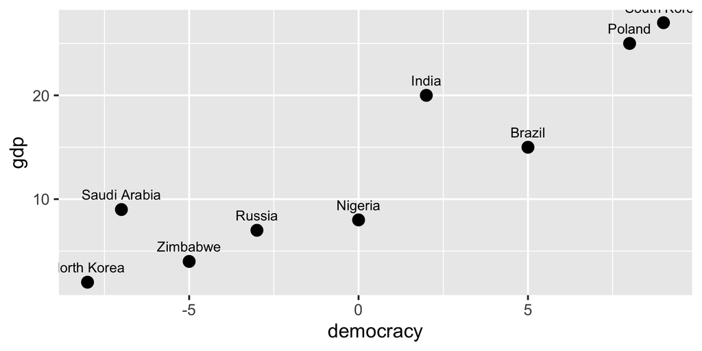

## Labs

### Adding Context with `labs()`

Now, we can improve readability:

```r
ggplot(eg1, aes(x = democracy, y = gdp)) +
  geom_point(size = 5) +
  geom_text(aes(label = country), vjust = -1, size = 5) +
  labs(
    title = "Democracy and Wealth",
    subtitle = "Higher democracy scores often align with higher GDP",
    x = "Democracy Score (-10 = Autocracy, +10 = Democracy)",
    y = "GDP per Capita (in $1,000s)",
    caption = "Toy dataset, inspired by real-world patterns"
  )
```

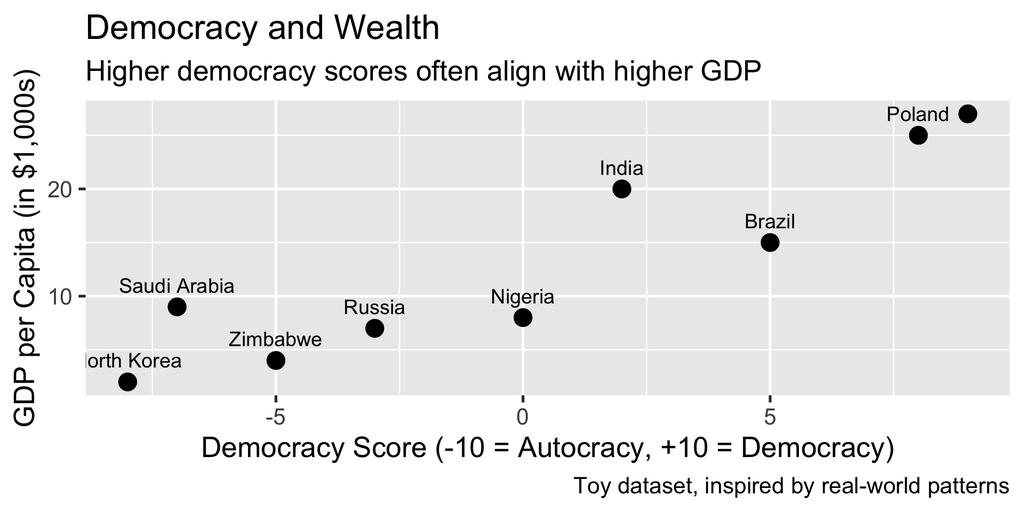

# Themes

## Themes

### What are Themes?

Control non-data elements of the plot.

Fonts, background, gridlines, legend placement, margins.

Do not affect the data → only the presentation.

Good themes = clarity + professionalism.

## Themes

### Built-in Themes: `theme_grey()`

Imagine we have data about 9 countries that record their level of democracy from -10 to +10 (x-axis) and their GDP per capita in $1,000s (y-axis).

```r
# Scatterplot with geom_point
ggplot(eg1, aes(x = democracy, y = gdp)) +
  geom_point(size = 5) +
  geom_text(aes(label = country), vjust = -1, size = 5) +
  theme_grey()
```

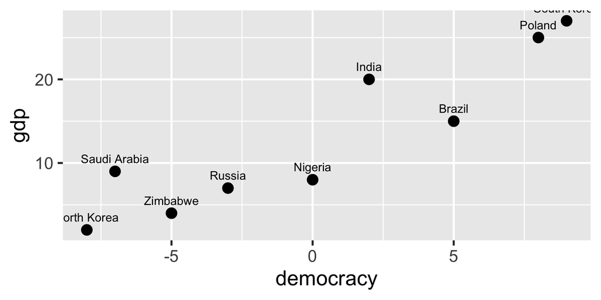

## Themes

### Built-in Themes: `theme_bw()`

Imagine we have data about 9 countries that record their level of democracy from -10 to +10 (x-axis) and their GDP per capita in $1,000s (y-axis).

```r
ggplot(eg1, aes(x = democracy, y = gdp)) +
  geom_point(size = 5) +
  geom_text(aes(label = country), vjust = -1, size = 5) +
  theme_bw()
```

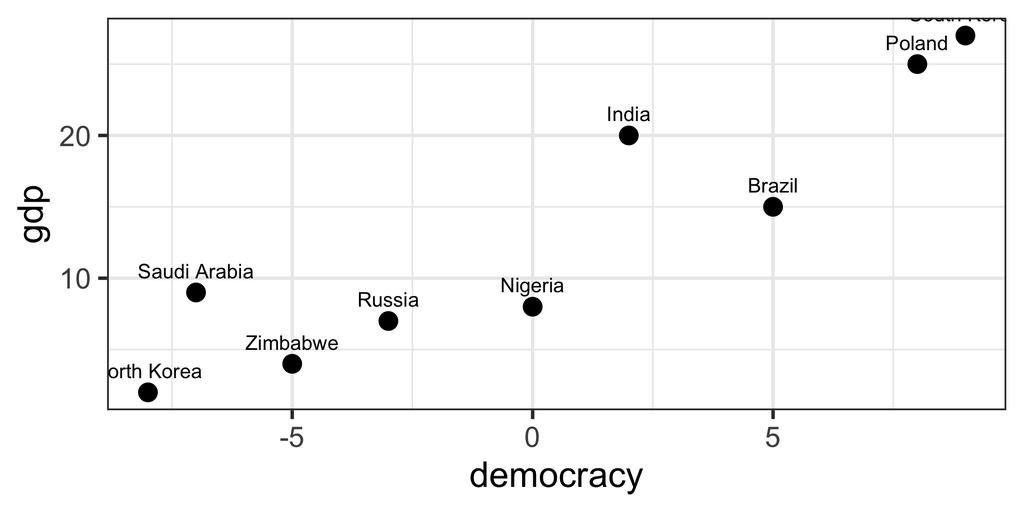

## Themes

### Built-in Themes: `theme_minimal()`

Imagine we have data about 9 countries that record their level of democracy from -10 to +10 (x-axis) and their GDP per capita in $1,000s (y-axis).

```r
ggplot(eg1, aes(x = democracy, y = gdp)) +
  geom_point(size = 5) +
  geom_text(aes(label = country), vjust = -1, size = 5) +
  theme_minimal()
```

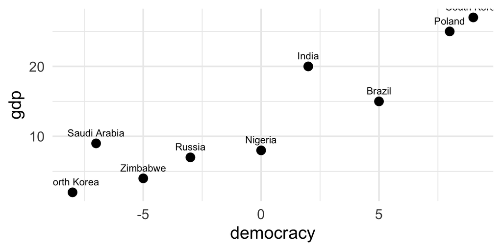

## Themes

### Built-in Themes: `theme_classic()`

Imagine we have data about 9 countries that record their level of democracy from -10 to +10 (x-axis) and their GDP per capita in $1,000s (y-axis).

```r
ggplot(eg1, aes(x = democracy, y = gdp)) +
  geom_point(size = 5) +
  geom_text(aes(label = country), vjust = -1, size = 5) +
  theme_classic()
```

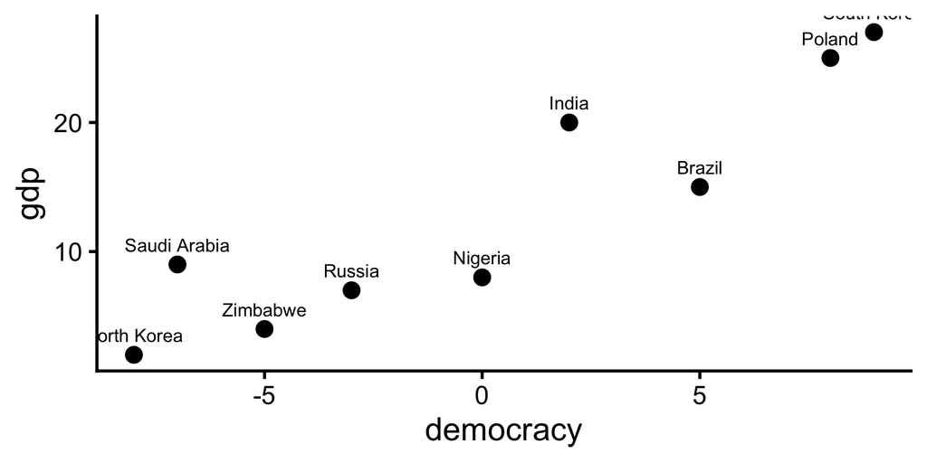

## Themes

### Built-in Themes: `theme_void()`

Imagine we have data about 9 countries that record their level of democracy from -10 to +10 (x-axis) and their GDP per capita in $1,000s (y-axis).

```r
ggplot(eg1, aes(x = democracy, y = gdp)) +
  geom_point(size = 5) +
  geom_text(aes(label = country), vjust = -1, size = 5) +
  theme_void()
```

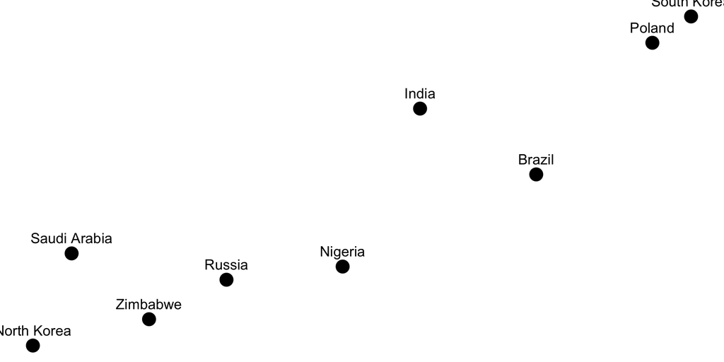

## Themes

### Supplementary Themes: `ggthemes` - `theme_economist`

To access additional themes you should install the `ggthemes` package

Imagine we have data about 9 countries that record their level of democracy from -10 to +10 (x-axis) and their GDP per capita in $1,000s (y-axis).

```r
library(ggthemes)
ggplot(eg1, aes(x = democracy, y = gdp)) +
  geom_point(size = 5) +
  geom_text(aes(label = country), vjust = -1, size = 5) +
  theme_economist()
```

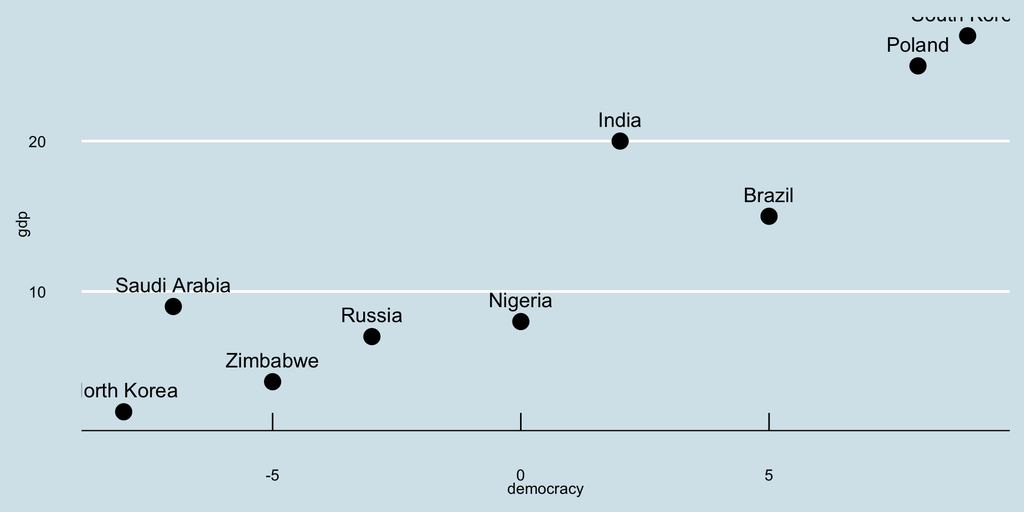

## Themes

### Supplementary Themes: `ggthemes` - `theme_wsj`

To access additional themes you should install the `ggthemes` package

Imagine we have data about 9 countries that record their level of democracy from -10 to +10 (x-axis) and their GDP per capita in $1,000s (y-axis).

```r
library(ggthemes)
ggplot(eg1, aes(x = democracy, y = gdp)) +
  geom_point(size = 5) +
  geom_text(aes(label = country), vjust = -1, size = 5) +
  theme_wsj()
```

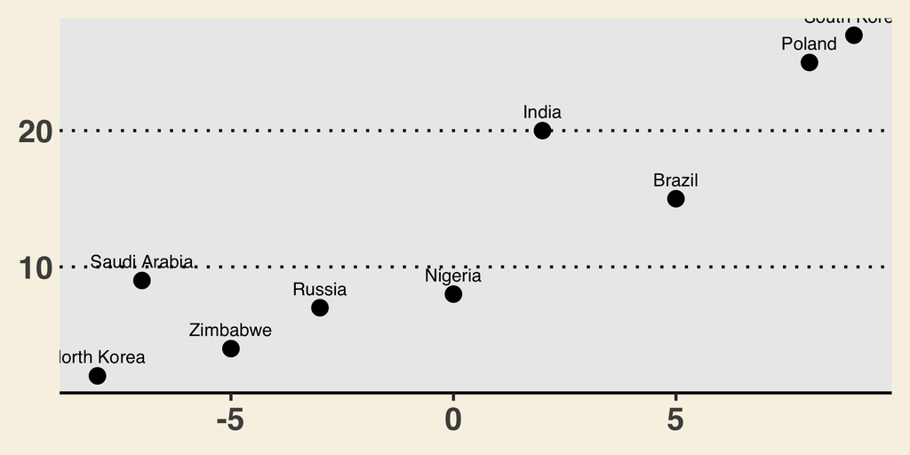

## Themes

### Tweaking a Theme

Imagine we have data about 9 countries that record their level of democracy from -10 to +10 (x-axis) and their GDP per capita in $1,000s (y-axis).

```r
# Scatterplot with geom_point
ggplot(eg1, aes(x = democracy, y = gdp)) +
  geom_point(size = 5) +
  geom_text(aes(label = country), vjust = -1, size = 5) +
  theme_minimal()+
  theme(panel.background = element_rect(fill = "white"), # Set background color
        axis.title.x = element_text(color = "#BF0404", face = "bold"), # Set x-axis label color
        axis.title.y = element_text(color = "#BF0404", face = "bold"),
        axis.line = element_line(color = "#BF0404", size = 1.5),
        panel.grid = element_blank(),
        panel.border = element_blank(),
        panel.grid.major.y = element_line(color = "#40403E", size = 0.5, linetype = "dotted"))
```

[figure not shown]

# Interactive Plots

## Interactive Plots

### Time Series

Suppose we have data on average voter turnout (%) in national elections over several years for the US and the UK. We want to see the trend in participation.

```r
set.seed(123)
library(gganimate)

# Toy dataset with US and UK
eg5 <- data.frame(
  year = rep(c(2000, 2004, 2008, 2012, 2016, 2020), times = 2),
  turnout = c(
    # US presidential elections
    54, 60, 62, 58, 56, 65,
    # UK general elections (closest years aligned to US election years for teaching)
    59, 61, 65, 66, 68, 67
  ),
  country = rep(c("United States", "United Kingdom"), each = 6)
)
```

## Interactive Plots

### Time Series

Suppose we have data on average voter turnout (%) in national elections over several years for the US and the UK. We want to see the trend in participation.

| year | turnout | country |
| --- | --- | --- |
| 2000 | 54 | United States |
| 2004 | 60 | United States |
| 2008 | 62 | United States |
| 2012 | 58 | United States |
| 2016 | 56 | United States |
| 2020 | 65 | United States |
| 2000 | 59 | United Kingdom |

## Interactive Plots

### Time Series

Suppose we have data on average voter turnout (%) in national elections over several years for the US and the UK. We want to see the trend in participation.

```r
ggplot(eg5, aes(x = year, y = turnout, color = country, group = country)) +
  geom_line() +
  transition_reveal(year)+
  labs(
    subtitle = "Year: {round(frame_along)}"
  )
```

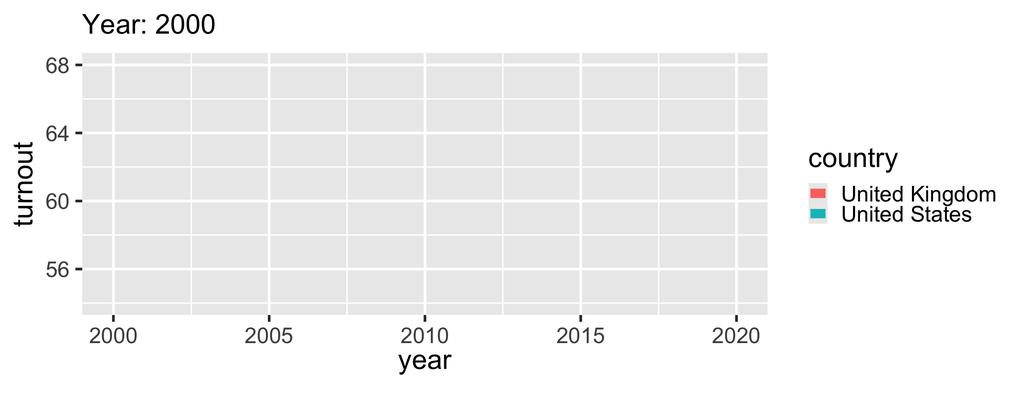

## Interactive Plots

### Time Scatterplots

Let us first create a panel data.

```r
library(dplyr)
library(tidyr)

# Base cross-section
eg1 <- data.frame(
  democracy = c(-8, -7, -5, -3, 0, 2, 5, 8, 9),   # democracy score
  gdp = c(2, 9, 4, 7, 8, 20, 15, 25, 27),  # GDP per capita ($1,000s)
  country = c(
    "North Korea",
    "Saudi Arabia",
    "Zimbabwe",
    "Russia",
    "Nigeria",
    "India",
    "Brazil",
    "Poland",
    "South Korea"
  )
)

# Add a fake panel (2000–2020 every 5 years)
set.seed(123)  # reproducible "wiggles"

eg_panel <- eg1 %>%
  slice(rep(1:n(), each = 5)) %>%           # repeat each country 5 times
  mutate(year = rep(seq(2000, 2020, 5), times = nrow(eg1))) %>%
  group_by(country) %>%
  mutate(
    # let democracy scores drift a bit
    democracy = democracy + cumsum(runif(5, -0.6, 0.3)),
    # let GDP grow with some noise
    gdp = gdp + cumsum(runif(5, 0, 2))
  )
```

## Interactive Plots

### Time Scatterplots

Let us first examine the data

| democracy | gdp | country | year |
| --- | --- | --- | --- |
| -7.790158 | 3.330230 | North Korea | 2000 |
| -8.168679 | 3.519912 | North Korea | 2005 |
| -8.730825 | 4.287851 | North Korea | 2010 |
| -9.035696 | 4.836618 | North Korea | 2015 |
| -8.776643 | 6.465898 | North Korea | 2020 |
| -6.733278 | 9.440238 | Saudi Arabia | 2000 |
| -6.521209 | 10.199871 | Saudi Arabia | 2005 |

## Interactive Plots

### Time Scatterplots

We learned to use `geom_text` in this example:

Imagine we have data about 9 countries that record their level of democracy from -10 to +10 (x-axis) and their GDP per capita in $1,000s (y-axis).

```r
# Scatterplot with geom_point
ggplot(eg_panel, aes(x = democracy, y = gdp, label = country)) +
  geom_point(size = 5) +
  geom_text(vjust = -1, size = 5, show.legend = FALSE) +
  labs(
    subtitle = "Year: {round(frame_time)}"
  ) +
  transition_time(round(year)) +
  ease_aes('linear')
```

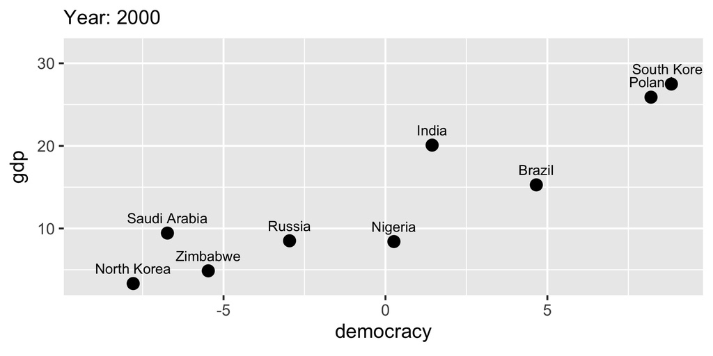

## Interactive Plots

### Interactive Maps

```r
library(ggplot2)
library(sf)
library(rnaturalearth)
library(rnaturalearthdata)
library(ggiraph)
library(glue)
library(scales)


world <- ne_countries(scale = "medium",
                      returnclass = "sf")
europe_bounds <- list(x = c(-10, 40),
                      y = c(35, 70))

# Mapping Them
# Interactive ggplot
p <- ggplot() +
  geom_sf_interactive(
    data = world,
    aes(
      fill = log(pop_est),
      tooltip = glue("{admin}: {comma(pop_est)}")  # hover text
    ),
    color = "white", linewidth = 0.1
  ) +
  coord_sf(
    xlim = europe_bounds$x,
    ylim = europe_bounds$y
  ) +
  theme_grey(base_size = 25) +
  scale_fill_viridis_c(option = "viridis")

# Render interactive plot with tooltips
girafe(ggobj = p)
```

[interactive chart not shown]

## Saving Figures

This was the first example we had:

Imagine we have data about 9 countries that record their level of democracy from -10 to +10 (x-axis) and their GDP per capita in $1,000s (y-axis).

```r
eg1 <- data.frame(
  democracy = c(-8, -7, -5, -3, 0, 2, 5, 8, 9),   # democracy score
  gdp = c(2, 9, 4, 7, 8, 20, 15, 25, 27)  # GDP per capita in $1,000s
)
```

## Saving Figures

We save the plot to an object and then print it:

```r
# Scatterplot with geom_point
pic<-ggplot(data=eg1,
       aes(x = democracy, y = gdp)) +
  geom_point()
print(pic)
```

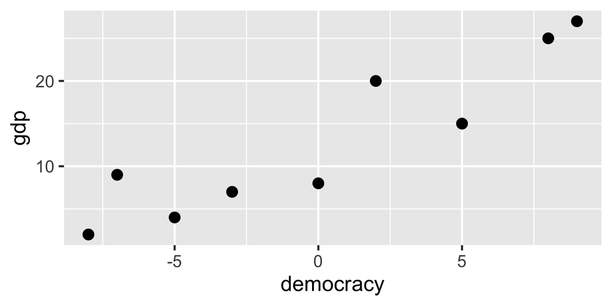

## Saving Figures

The command to save a picture is `ggsave`

We can save it as:

- PDF → small file, best for documents and printing

```r
# Square picture
ggsave(pic, filename = "pic.pdf")
```

- PNG → crisp, good for websites or presentations

```r
ggsave(pic, filename = "pic.png")
```

- JPG → also common, but usually larger file size

```r
ggsave(pic, filename = "pic.jpg")
```

## Saving Figures

### Controlling Shape

When you save, you can tell R how wide and tall the picture should be.

```r
ggsave(pic, filename = "pic_square.png", width = 20, height = 20, units = "cm")
```

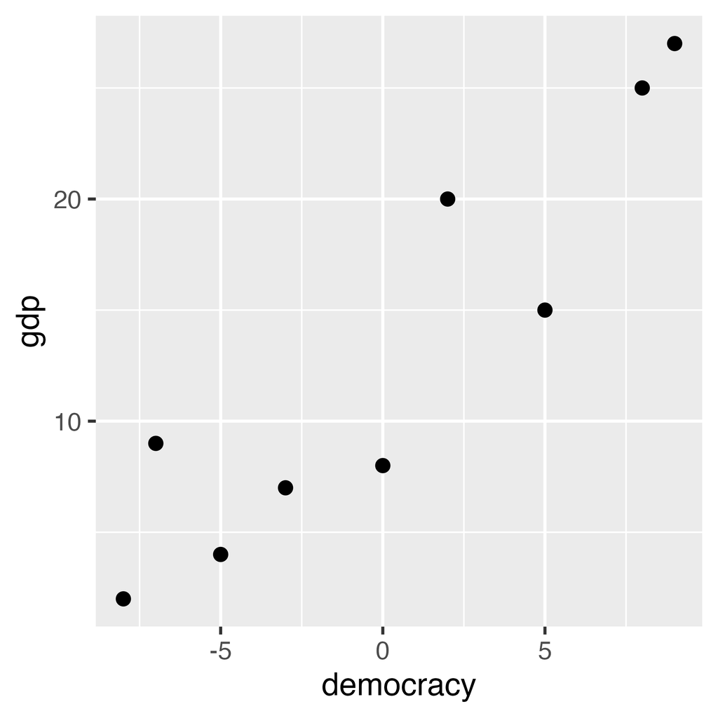

## Saving Figures

### Controlling Shape

When you save, you can tell R how wide and tall the picture should be.

```r
ggsave(pic, filename = "pic_height.png", width = 10, height = 20, units = "cm")
```

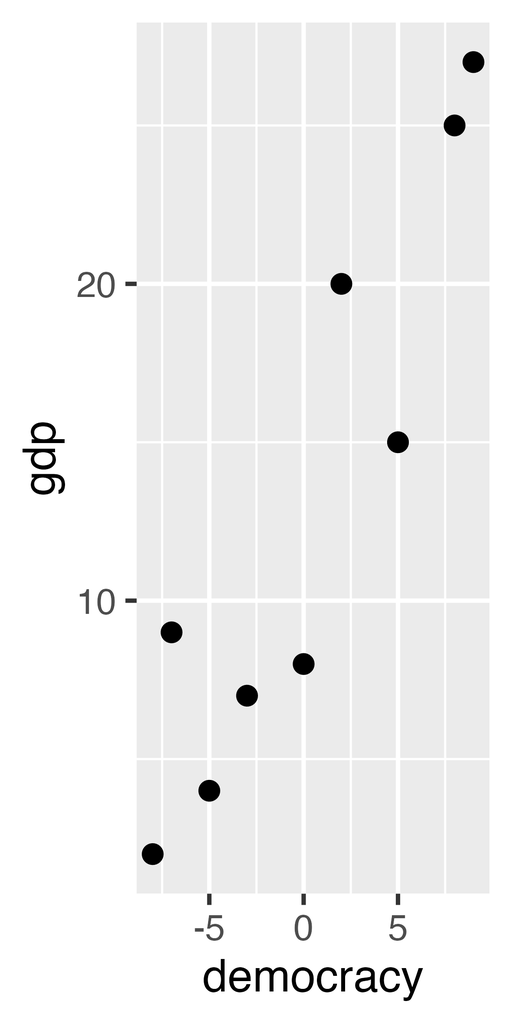